# hpgltools examples

atb abelew@gmail.com

2015-07-31

# Example hpgltool usage with a real data set (fission)

This document aims to provide further examples in how to use the hpgltools.

## Setting up

Here are the commands I invoke to get ready to play with new data, including everything required to install hpgltools, the software it uses, and the fission data.

```r
## These first 4 lines are not needed once hpgltools is installed.
##source("http://bioconductor.org/biocLite.R")
##biocLite("devtools")
##library(devtools)
##install_github("elsayed-lab/hpgltools")
library(hpgltools)
autoloads_all()
```

[output not shown]

```
##
## groupGOTerms:    GOBPTerm, GOMFTerm, GOCCTerm environments built.
```

```r
require.auto("fission")
library(fission)
data(fission)
opts_knit$set(progress=TRUE, verbose=TRUE, error=TRUE,  fig.width=7, fig.height=7)
```

## Data import

All the work I do in Dr. El-Sayed’s lab makes some pretty hard assumptions about how data is stored. As a result, to use the fission data set I will do a little bit of shenanigans to match it to the expected format. Now that I have played a little with fission, I think its format is quite nice and am likely to have my experiment class instead be a SummarizedExperiment.

```r
## Extract the meta data from the fission dataset
meta = as.data.frame(fission@colData)
## Make conditions and batches
meta$condition = paste(meta$strain, meta$minute, sep=".")
meta$batch = meta$replicate
meta$sample.id = rownames(meta)
## Write it out in the format expected by my toys
write.csv(meta, file="fission.csv")
## Grab the count data
fission_data = fission@assays$data$counts
## This will make an experiment superclass called 'expt' and it contains
## an ExpressionSet along with any arbitrary additional information one might want to include.
## Along the way it writes a Rdata file which is by default called 'expt.Rdata'
fission_expt = create_expt("fission.csv", count_dataframe=fission_data)
```

```
## [1] "This function needs the conditions and batches to be an explicit column in the sample sheet."
## [1] "Please note that thus function assumes a specific set of columns in the sample sheet:"
## [1] "The most important ones are: Sample.ID, Stage, Type."
## [1] "Other columns it will attempt to create by itself, but if"
## [1] "batch and condition are provided, that is a nice help."
```

## Normalizing and exploring data

There are lots of toys we have learned to use to play with with raw data and explore stuff like batch effects or non-canonical distributions or skewed counts. hpgltools provides some functionality to make this process easier. The graphs shown below and many more are generated with the wrapper ‘graph_metrics()’ but that takes away the chance to explain the graphs as I generate them.

```r
## First make a bar plot of the library sizes in the experiment.
## Notice that the colors were auto-chosen by create_expt() and they should
## be maintained throughout this process
fis_libsize = hpgl_libsize(fission_expt)
```

```
## Adding log10
```

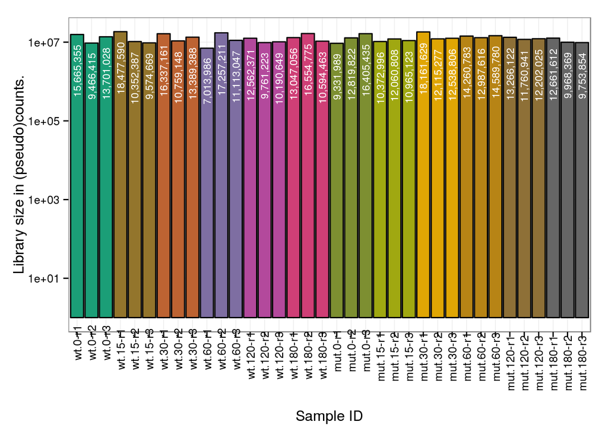

```r
fis_libsize
```

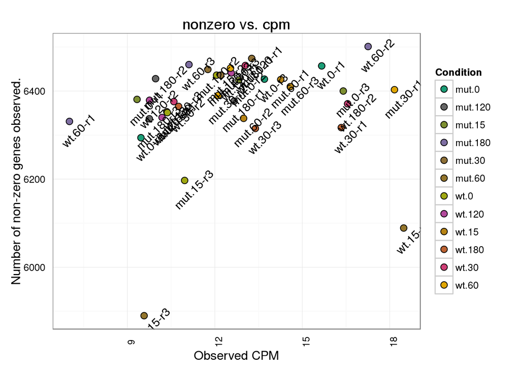

```r
## Here we see that the wild type replicate 3 sample for 15 minutes has fewer non-zero genes than all its friends.
fis_nonzero = hpgl_nonzero(fission_expt, labels="boring", title="nonzero vs. cpm")
fis_nonzero
```

### An initial pca plot

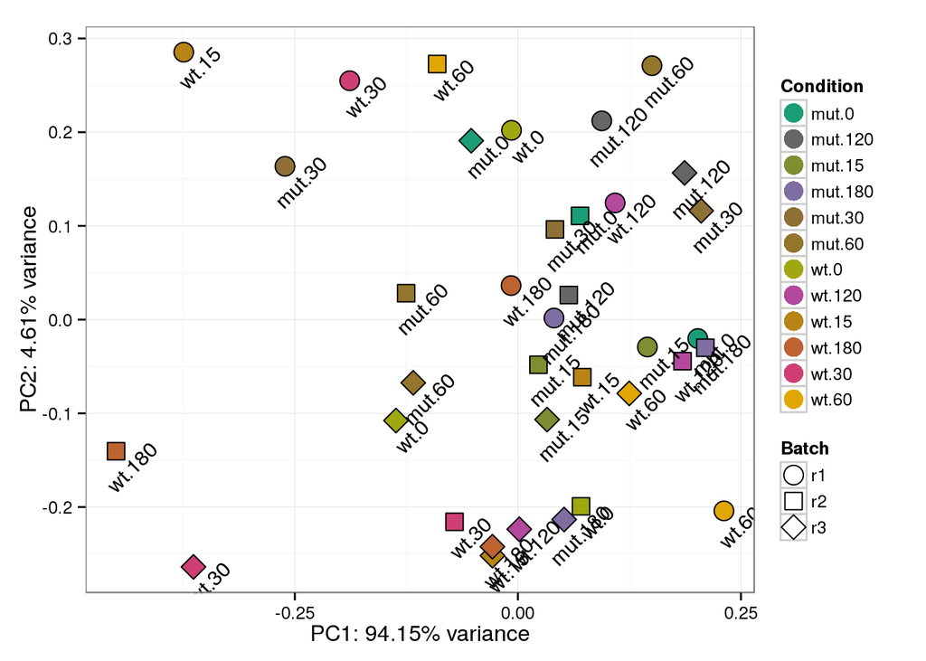

```r
## Unsurprisingly, the raw data doesn't cluster well at all...
fis_rawpca = hpgl_pca(fission_expt, labels=fission_expt$condition)
fis_rawpca$plot
```

```r
## So, normalize the data
norm_expt = normalize_expt(fission_expt)
```

[output not shown]

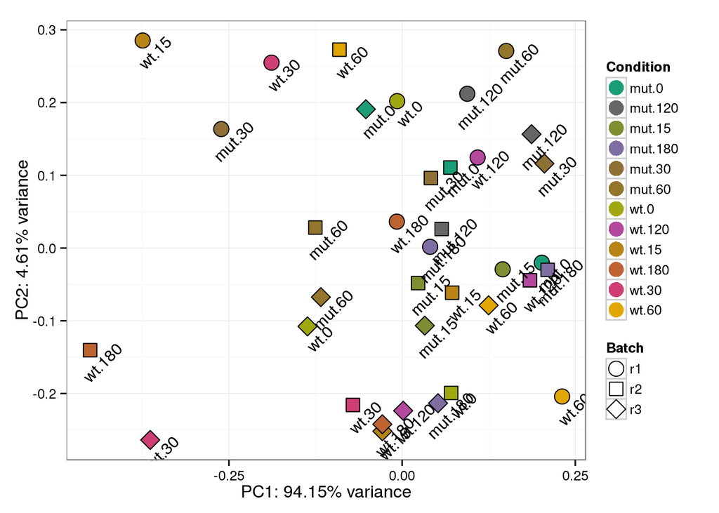

```r
## And try the pca again
fis_normpca = hpgl_pca(norm_expt, labels=norm_expt$condition)
fis_normpca$plot
```